# 6 Generalized linear models I

true  
2022-05-10

## Generalized linear models

Recall our formulation of a linear model:

$$\Large y_i \sim
\text{Normal}(\mu_i,\sigma)$$
$$\Large
\mu_i = \beta_0 + \beta x_i$$

Notice that there is no constraint on the outcome of the operations on the right hand side. This was not an issue in the cases we saw so far, because $\mu_i$ could, in principle, be 5; 50; 600; 234.5 or 234.5634233. However, not all parameters and outcomes can take just any value.

If we are predicting how likely an event is to occur, the outcome is between $0$ and $1$. It doesn’t make sense to predict that the event will occur with a probability of $24.54$ or with a probability of $-1$. Similarly, if we are predicting how many times an event occurred, the rate of occurrence is $0$ or higher. It doesn’t make sense to predict the event is expected to occur at a rate of $-5$. The kind of constraint we need on the right-hand side thus depends on the distribution we’re taking as a starting point (what the parameter on the left represents).

A *generalized* linear model is a model that takes the values on the right and applies a transformation to them to fulfill such a constraint. So far, we didn’t have to apply any constraints because $y$ was distributed following a Normal distribution. But now we also want to make predictions about Bernoulli distributed and Poisson distributed outcomes. Recall that they look like this:

$$\Large y_i \sim
\text{Poisson}(\lambda_i)$$
$$\Large
y_i \sim \text{Bernoulli}(p_i)$$
For count data (Poisson distributed), the canonical function that constraints the estimates to suit the distribution is the exponential function.

$$\Large y_i \sim
\text{Poisson}(\lambda_i)$$
$$\Large
\lambda_i = \text{exp}(\beta_0 + \beta x_i)$$
For probabilities (Bernoulli distributed), the canonical function that constraints the estimates to suit the distribution is the so-called inverse logit function.

$$\Large y_i \sim
\text{Bernoulli}(p_i)$$
$$\Large p_i =
\frac{\text{exp}(\beta_0 + \beta x_i)}{1 + \text{exp}(\beta_0 + \beta
x_i)}$$

In this session, we will look at count data, using a Generalized Linear Model and the Poisson distribution

#### Case study: Gestures

Let’s use the study of Brown et al. (n.d.) to exemplify a regression for count data.

```r
### Packages we will use ###
library(dplyr)
library(ggplot2)
### ### ###

df <- read.csv('https://tinyurl.com/gestures-data') #download data
glimpse(df) #get a look at the data
```

```
Rows: 54
Columns: 6
$ ID       <chr> "Catalan_1", "Catalan_1", "Catalan_2", "Catalan_2",…
$ context  <chr> "friend", "prof", "friend", "prof", "friend", "prof…
$ dur      <int> 137, 136, 90, 107, 181, 165, 130, 115, 122, 125, 16…
$ language <chr> "Catalan", "Catalan", "Catalan", "Catalan", "Catala…
$ gender   <chr> "M", "M", "F", "F", "M", "M", "M", "M", "F", "F", "…
$ gestures <int> 61, 78, 31, 40, 81, 49, 32, 49, 39, 32, 35, 30, 88,…
```

We focus on the number of `gestures` (outcome / $y$), with `language`, `gender` and `context` as possible predictors.

Let’s again first visualize the data to get a sense whether it even makes sense to predict number of gestures with any of these predictors:

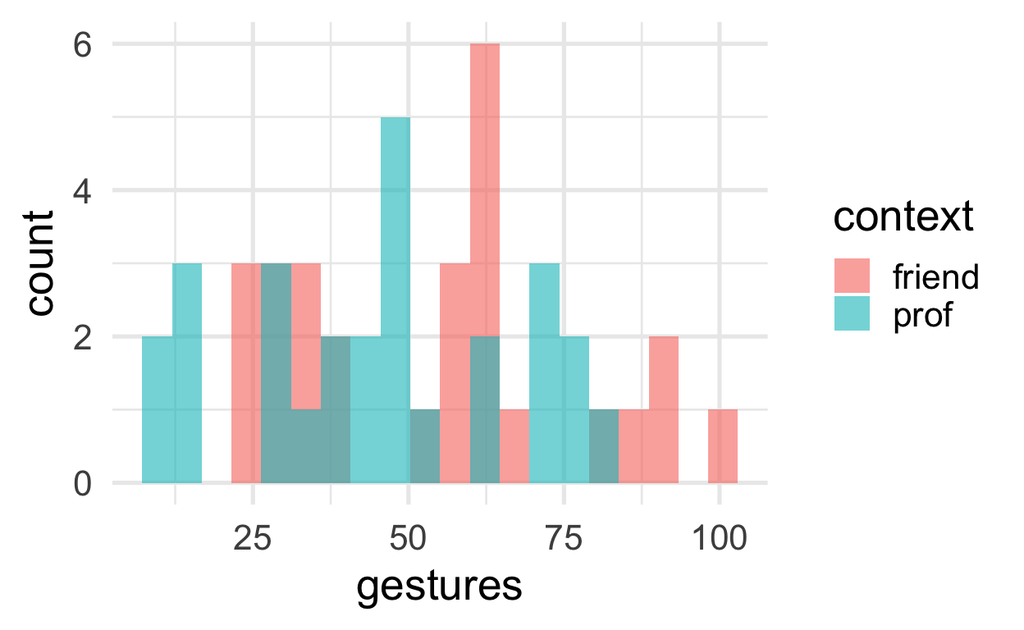

```r
ggplot(df, aes(x = gestures, fill = context)) +
         geom_histogram(bins=20, alpha=0.6, position='identity') +
         theme_minimal(base_size=20)
```

And the same for language:

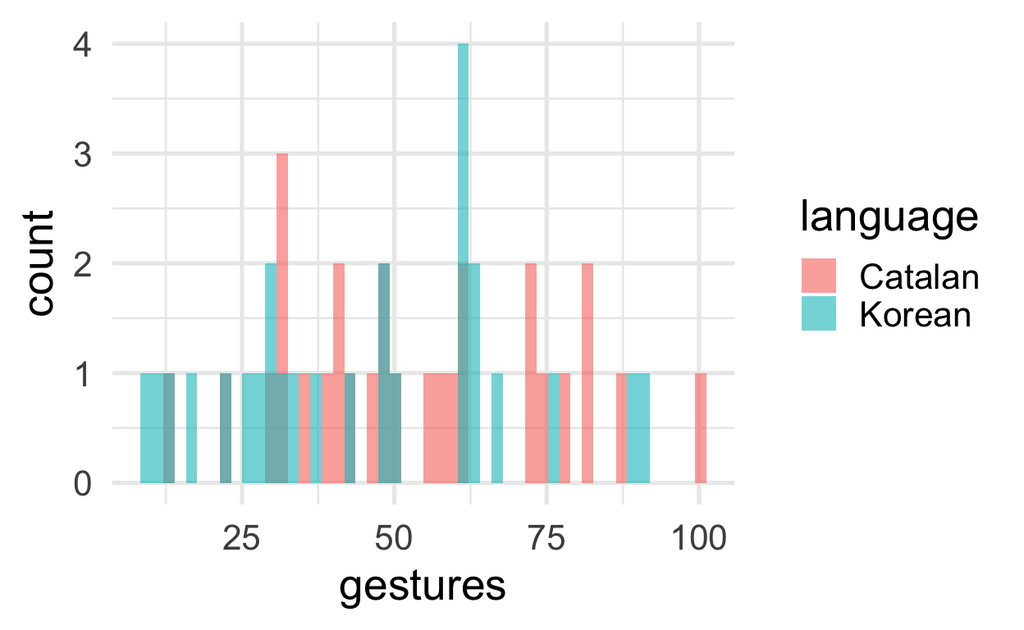

```r
ggplot(df, aes(x = gestures, fill = language)) +
         geom_histogram(bins=50, alpha=0.6, position='identity') +
         theme_minimal(base_size=20)
```

And gender:

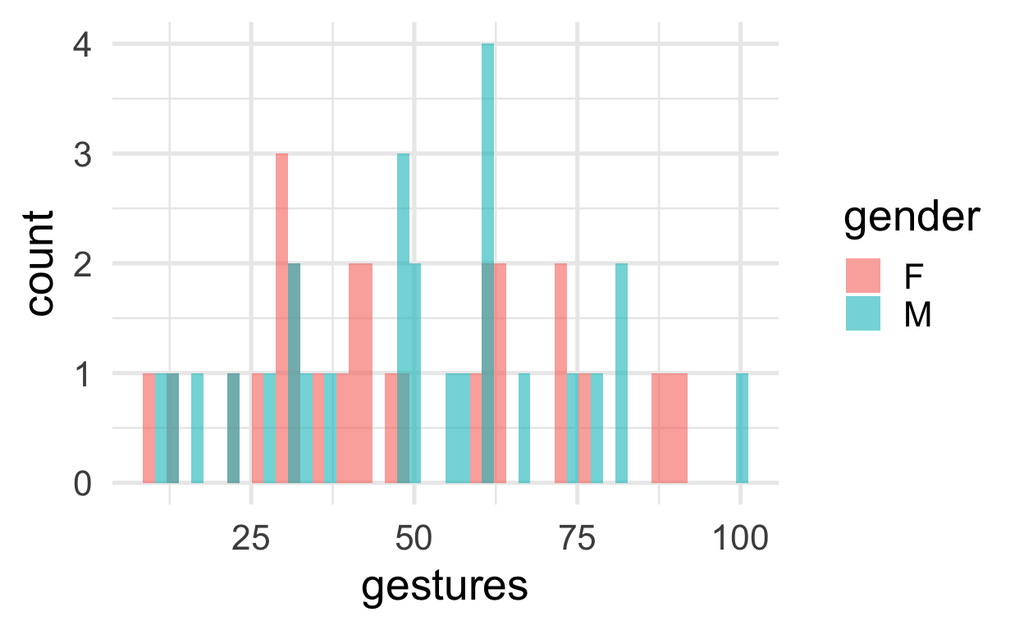

```r
ggplot(df, aes(x = gestures, fill = gender)) +
         geom_histogram(bins=50, alpha=0.6, position='identity') +
         theme_minimal(base_size=20)
```

Let’s first build each model individually

```r
#Notice that we're now using a function called glm()
#Notice that we now specify the family of the model (Poisson)
#Notice that we now specify the link function (log)

gestures_context <- glm(formula = gestures ~ 1 + context,
                       data    = df,
                       family  = poisson(link = 'log')
                        )
summary(gestures_context)
```

```
Call:
glm(formula = gestures ~ 1 + context, family = poisson(link = "log"),
    data = df)

Deviance Residuals:
    Min       1Q   Median       3Q      Max
-6.3272  -2.8687   0.4296   1.6026   5.7274

Coefficients:
            Estimate Std. Error z value Pr(>|z|)
(Intercept)  3.98555    0.02623 151.923  < 2e-16 ***
contextprof -0.17724    0.03886  -4.561 5.08e-06 ***
---
Signif. codes:  0 '***' 0.001 '**' 0.01 '*' 0.05 '.' 0.1 ' ' 1

(Dispersion parameter for poisson family taken to be 1)

    Null deviance: 583.97  on 53  degrees of freedom
Residual deviance: 563.08  on 52  degrees of freedom
AIC: 870.22

Number of Fisher Scoring iterations: 4
```

Interpreting the coefficient is a little more difficult now. Before we could just read off the intercept’s and predictor’s contributions, but now everything happens in the *log*-space. The predicted number of gestures of a speaker in a professional context is:

$$\Large \text{log}(\lambda_i) \approx
3.99 - 0.178 \approx 3.812$$
For an informal context, the prediction is accordingly just $3.99$.

However, this is $\text{log}(\lambda_i)$ and not $\lambda_i$. So this is the logarithm of the expected number of gestures in both contexts. To get a non-logarithmic (and easier to interpret) prediction, take the inverse of the logarithm: the exponent.

```r
exp(3.99 - 0.178) #expected number of gestures in a polite context
```

```
[1] 45.24083
```

```r
exp(3.99)         #expected number of gestures in an informal context
```

```
[1] 54.05489
```

Keeping this in mind, we fit the remaining two univariate models:

```r
gestures_lang <- glm(formula = gestures ~ 1 + language,
                       data    = df,
                       family  = poisson(link = 'log')
                        )

summary(gestures_lang)
```

```
Call:
glm(formula = gestures ~ 1 + language, family = poisson(link = "log"),
    data = df)

Deviance Residuals:
    Min       1Q   Median       3Q      Max
-6.6496  -2.6240  -0.4041   2.4834   6.0006

Coefficients:
               Estimate Std. Error z value Pr(>|z|)
(Intercept)     3.97968    0.02584 154.030  < 2e-16 ***
languageKorean -0.17131    0.03900  -4.393 1.12e-05 ***
---
Signif. codes:  0 '***' 0.001 '**' 0.01 '*' 0.05 '.' 0.1 ' ' 1

(Dispersion parameter for poisson family taken to be 1)

    Null deviance: 583.97  on 53  degrees of freedom
Residual deviance: 564.56  on 52  degrees of freedom
AIC: 871.7

Number of Fisher Scoring iterations: 4
```

```r
gestures_context <- glm(formula = gestures ~ 1 + gender,
                       data    = df,
                       family  = poisson(link = 'log')
                        )
summary(gestures_context)
```

```
Call:
glm(formula = gestures ~ 1 + gender, family = poisson(link = "log"),
    data = df)

Deviance Residuals:
    Min       1Q   Median       3Q      Max
-6.7432  -2.7667  -0.2118   1.9619   6.2463

Coefficients:
            Estimate Std. Error z value Pr(>|z|)
(Intercept)  3.88083    0.02715 142.961   <2e-16 ***
genderM      0.04115    0.03871   1.063    0.288
---
Signif. codes:  0 '***' 0.001 '**' 0.01 '*' 0.05 '.' 0.1 ' ' 1

(Dispersion parameter for poisson family taken to be 1)

    Null deviance: 583.97  on 53  degrees of freedom
Residual deviance: 582.84  on 52  degrees of freedom
AIC: 889.98

Number of Fisher Scoring iterations: 4
```

In words, being a speaker of Korean suggests less gestures than being a speaker of Catalan. But gender (alone) seems to be a bad predictor of number of gestures.

Let’s look at a model with all three predictors

```r
gestures_all <- glm(formula = gestures ~ 1 + context + language + gender,
                       data    = df,
                       family  = poisson(link = 'log')
                        )
summary(gestures_all)
```

```
Call:
glm(formula = gestures ~ 1 + context + language + gender, family = poisson(link = "log"),
    data = df)

Deviance Residuals:
    Min       1Q   Median       3Q      Max
-6.1975  -2.7275  -0.0876   2.2215   5.4705

Coefficients:
               Estimate Std. Error z value Pr(>|z|)
(Intercept)     4.04691    0.03701 109.355  < 2e-16 ***
contextprof    -0.17724    0.03886  -4.561 5.08e-06 ***
languageKorean -0.16998    0.03903  -4.356 1.33e-05 ***
genderM         0.03465    0.03874   0.894    0.371
---
Signif. codes:  0 '***' 0.001 '**' 0.01 '*' 0.05 '.' 0.1 ' ' 1

(Dispersion parameter for poisson family taken to be 1)

    Null deviance: 583.97  on 53  degrees of freedom
Residual deviance: 542.87  on 50  degrees of freedom
AIC: 854.01

Number of Fisher Scoring iterations: 4
```

# Goodness of fit: Information criteria

The AIC (Akaike Information Criterion) estimates out-of-sample prediction error. It provides a relative measure of model quality, penalizing for for model complexity. Lower is better.

# Further reading

The paper [Poisson regression for linguists: A tutorial introduction to modeling count data with brms](https://osf.io/93kaf/) discusses Poisson regression using the same data.

## Corrections

If you spot a mistake or have suggestions, please get in touch with [Thomas Brochhagen](https://brochhagen.github.io) or [create an issue](https://github.com/metodesempirics/metodesempirics.github.io/issues/new)

Brown, L, H Kim, I Hübscher, and B Winter. n.d. “Iconic Gestures Are Modulated by Social Context: A Study of Multimodal Politeness Across Two Cultures.” *Gesture*.